# Отчет по лабораторной работе №8

Поиск файлов. Перенаправление ввода-вывода. Просмотр запущенных процессов

Виноградова М.А

Российский университет дружбы народов, Москва, Россия

2 апреля 2025

# Информация

## Докладчик

- Виноградова Мария Андреевна
- студентка НПИбд-01-24
- номер студ. билета 1132240691
- Российский университет дружбы народов
- 1132240691@pfur.ru
- https://github.com/mavinogradova/study_2024-2025_os-intro

## Цель работы

Ознакомление с инструментами поиска файлов и фильтрации текстовых данных.Приобретение практических навыков: по управлению процессами (и заданиями), по проверке использования диска и обслуживанию файловых систем.

# Выполнение лабораторной работы

## Осуществите вход в систему, используя соответствующее имя пользователя.

## Запишите в файл file.txt названия файлов, содержащихся в каталоге /etc.

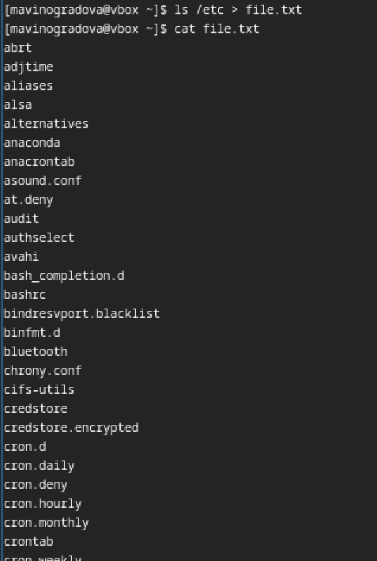

Записываем названия файлов

## Допишите в этот же файл названия файлов, содержащихся в вашем домашнем каталоге

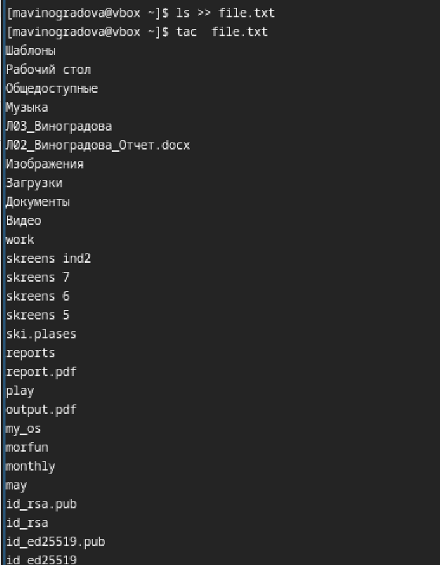

Дописываем названия файлов

## Выведите имена всех файлов из file.txt, имеющих расширение .conf.

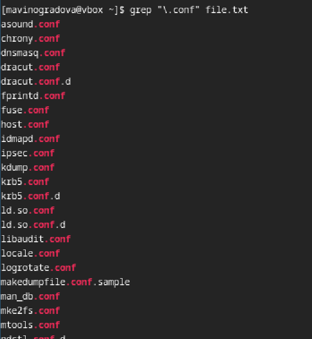

Выводим имена файлов

## После чего запишите их в новый текстовой файл conf.txt.

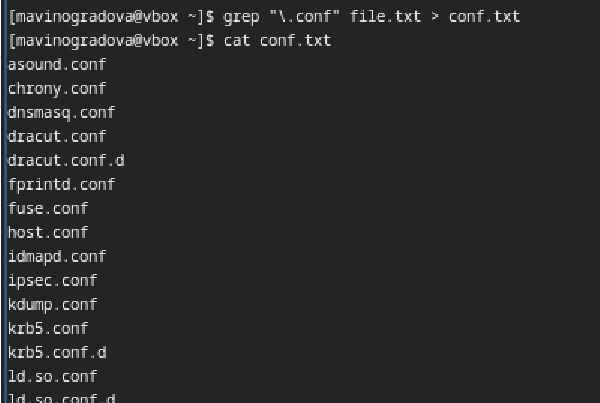

Записываем имена файлов

## Определите, какие файлы в вашем домашнем каталоге имеют имена, начинавшиеся с символа c? Предложите несколько вариантов, как это сделать.

### Вариант 1:

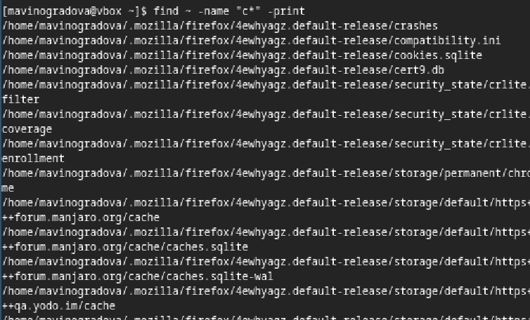

Первый вариант поиска файлов с названием на с

### Вариант 2:

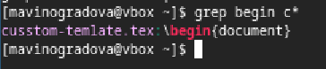

Второй вариант поиска файлов с названием на с

### Вариант 3:

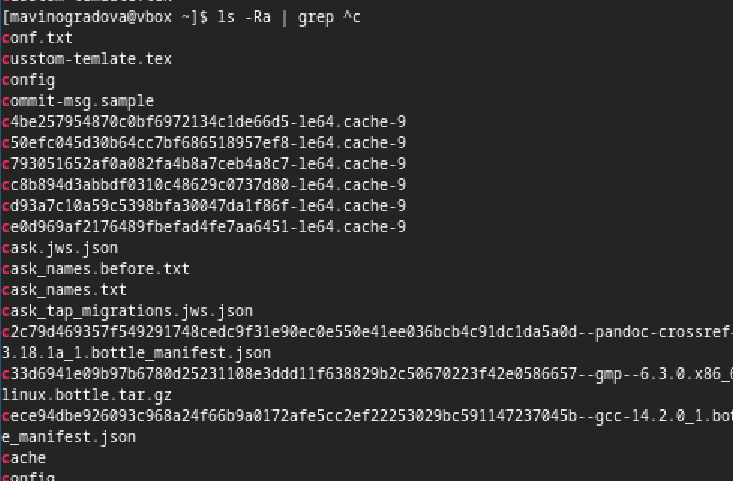

Третий вариант поиска файлов с названием на с

## Выведите на экран (по странично) имена файлов из каталога /etc, начинающиеся с символа h.

[figure not shown]

## Запустите в фоновом режиме процесс, который будет записывать в файл ~/logfile файлы, имена которых начинаются с log.

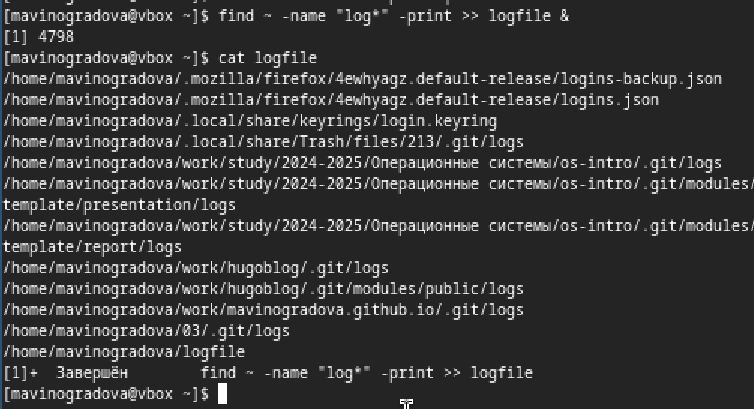

Запускаем процесс в фоновом режиме

## Удалите файл ~/logfile.

Использовала команду rm logfile

## Запустите из консоли в фоновом режиме редактор gedit.

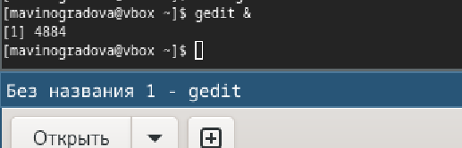

Запускаем gedit в фоновом режиме

## Определите идентификатор процесса gedit, используя команду ps, конвейер и фильтр grep. Как ещё можно определить идентификатор процесса?

[figure not shown]

## Прочтите справку (man) команды kill, после чего используйте её для завершения процесса gedit.

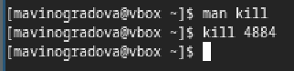

Команда kill

## Выполните команды df и du, предварительно получив более подробную информацию об этих командах, с помощью команды man.

### Получение подробной инфориации:

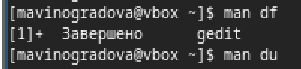

Использование команды man

[figure not shown]

### Команда du:

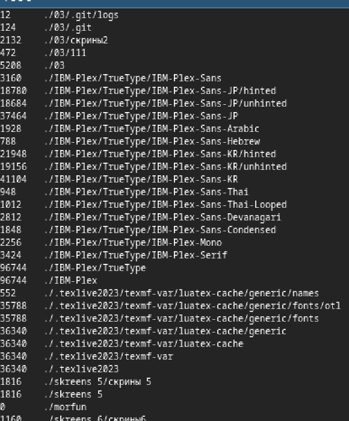

du

## Воспользовавшись справкой команды find, выведите имена всех директорий, имеющихся в вашем домашнем каталоге.

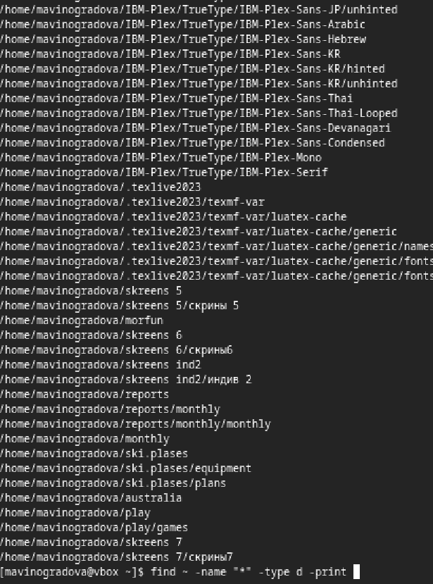

Выводим имена директорий